# Wages and Races

Prajwal Vijendra

September 19, 2018

```r
library(tidyverse)
wages_df<-  read.csv("Dataset/Ex1029.csv")

head(wages_df)
```

```
##   X   Wage Education Experience Black SMSA Region
## 1 1 354.94         7         45    No  Yes     NE
## 2 2 370.37         9          9    No  Yes     NE
## 3 3 754.94        11         46    No  Yes     NE
## 4 4 593.54        12         36    No  Yes     NE
## 5 5 377.23        16         22    No  Yes     NE
## 6 6 284.90         8         51    No  Yes     NE
```

```r
summary(wages_df)
```

```
##        X              Wage            Education       Experience
##  Min.   :    1   Min.   :   50.39   Min.   : 0.00   Min.   :-4.00
##  1st Qu.: 6408   1st Qu.:  356.13   1st Qu.:12.00   1st Qu.: 9.00
##  Median :12816   Median :  567.23   Median :12.00   Median :16.00
##  Mean   :12816   Mean   :  640.16   Mean   :13.08   Mean   :18.59
##  3rd Qu.:19224   3rd Qu.:  826.21   3rd Qu.:16.00   3rd Qu.:27.00
##  Max.   :25631   Max.   :18777.20   Max.   :18.00   Max.   :63.00
##  Black        SMSA       Region
##  No :23643   No : 6591   MW:6226
##  Yes: 1988   Yes:19040   NE:5949
##                          S :7991
##                          W :5465
##
##
```

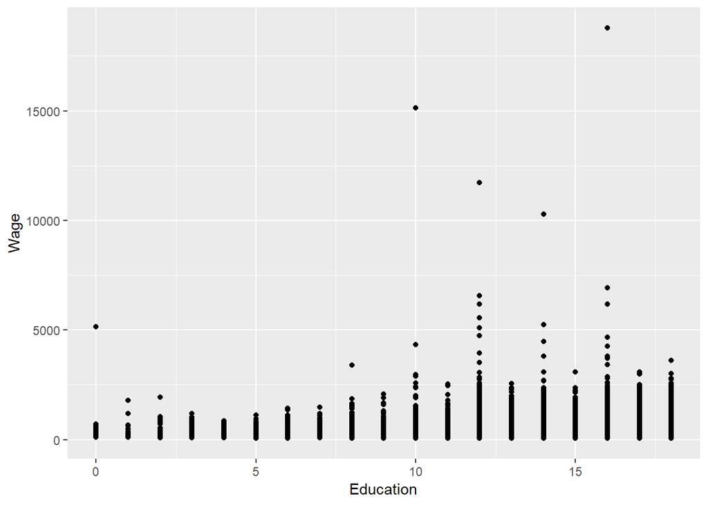

```r
ggplot(data = wages_df) + geom_point(mapping = aes(x = Education, y = Wage))
```

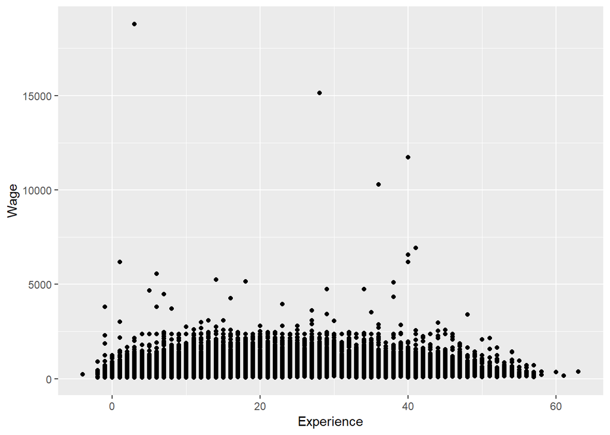

```r
ggplot(data = wages_df) + geom_point(mapping = aes(x = Experience, y = Wage))
```

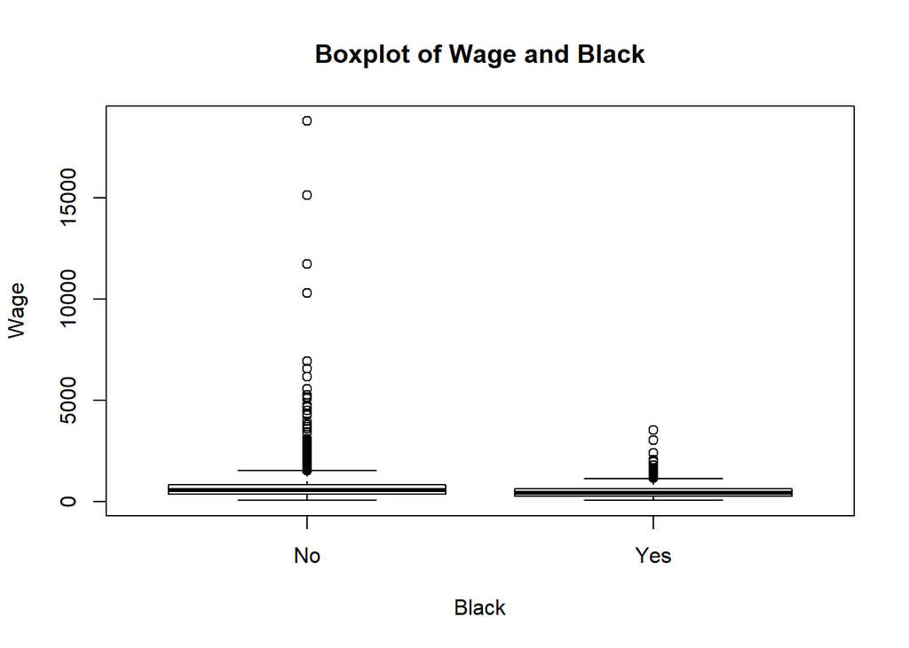

```r
boxplot(Wage~Black, data = wages_df, xlab = "Black", ylab = "Wage", main = "Boxplot of Wage and Black")
```

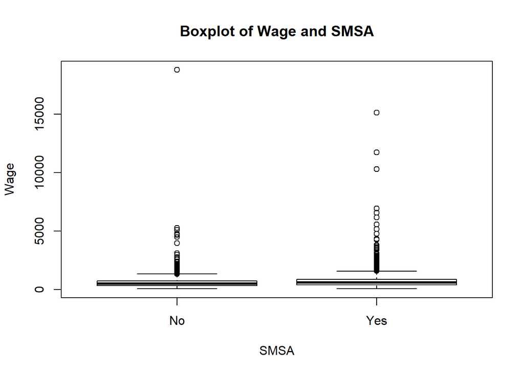

```r
boxplot(Wage~SMSA, data = wages_df, xlab = "SMSA", ylab = "Wage", main = "Boxplot of Wage and SMSA")
```

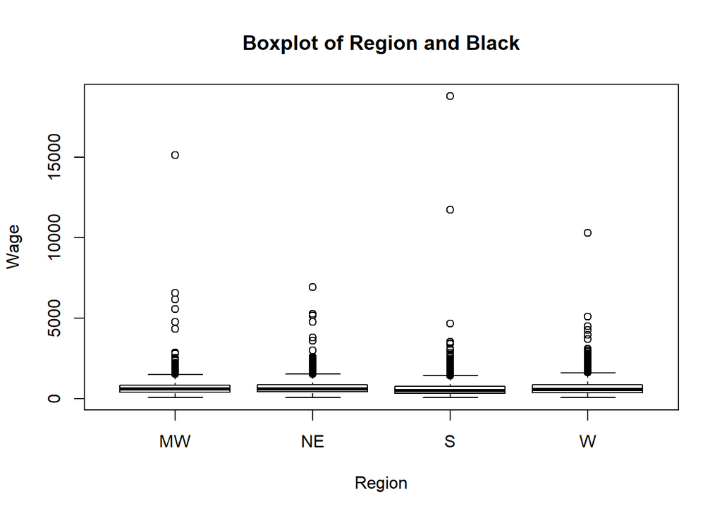

```r
boxplot(Wage~Region, data = wages_df, xlab = "Region", ylab = "Wage", main = "Boxplot of Region and Black")
```

Looking at all the scatter and box plots it shows the signs of non-linearity and non constant variance. Also, it helps to take the log of Wages.

Lets create a bwplot to see if there is any interaction between variables.

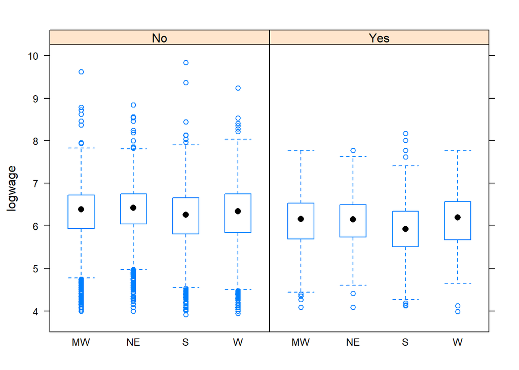

```r
wages_df$logwage = log(wages_df$Wage)

library(lattice)
bwplot(logwage~Region | Black, data = wages_df)
```

Looking at the bwplot, the plots are very similar to each other and hence doesnt show any interactions between the varaibles. Lets confirm this by a nested F test.

Lets create 2 linear models one without the interactions and other with the interactions and then perform nested F test.

```r
regwage = lm(logwage ~ Education + Experience + as.factor(Black) + as.factor(SMSA) + as.factor(Region) , data= wages_df)

summary(regwage)
```

```
##
## Call:
## lm(formula = logwage ~ Education + Experience + as.factor(Black) +
##     as.factor(SMSA) + as.factor(Region), data = wages_df)
##
## Residuals:
##     Min      1Q  Median      3Q     Max
## -2.6934 -0.3021  0.0445  0.3457  3.7178
##
## Coefficients:
##                       Estimate Std. Error t value Pr(>|t|)
## (Intercept)          4.5764173  0.0197020 232.281  < 2e-16 ***
## Education            0.0970151  0.0012011  80.773  < 2e-16 ***
## Experience           0.0183511  0.0002789  65.810  < 2e-16 ***
## as.factor(Black)Yes -0.2304380  0.0126570 -18.206  < 2e-16 ***
## as.factor(SMSA)Yes   0.1578088  0.0077105  20.467  < 2e-16 ***
## as.factor(Region)NE  0.0359518  0.0097111   3.702 0.000214 ***
## as.factor(Region)S  -0.0611603  0.0090699  -6.743 1.58e-11 ***
## as.factor(Region)W  -0.0017984  0.0098616  -0.182 0.855298
## ---
## Signif. codes:  0 '***' 0.001 '**' 0.01 '*' 0.05 '.' 0.1 ' ' 1
##
## Residual standard error: 0.5314 on 25623 degrees of freedom
## Multiple R-squared:  0.2827, Adjusted R-squared:  0.2825
## F-statistic:  1443 on 7 and 25623 DF,  p-value: < 2.2e-16
```

```r
confint(regwage)
```

```
##                           2.5 %      97.5 %
## (Intercept)          4.53780024  4.61503444
## Education            0.09466092  0.09936932
## Experience           0.01780458  0.01889771
## as.factor(Black)Yes -0.25524646 -0.20562960
## as.factor(SMSA)Yes   0.14269587  0.17292178
## as.factor(Region)NE  0.01691743  0.05498621
## as.factor(Region)S  -0.07893782 -0.04338273
## as.factor(Region)W  -0.02112764  0.01753083
```

The value of r_squared is 0.2827 and SE is 0.5314

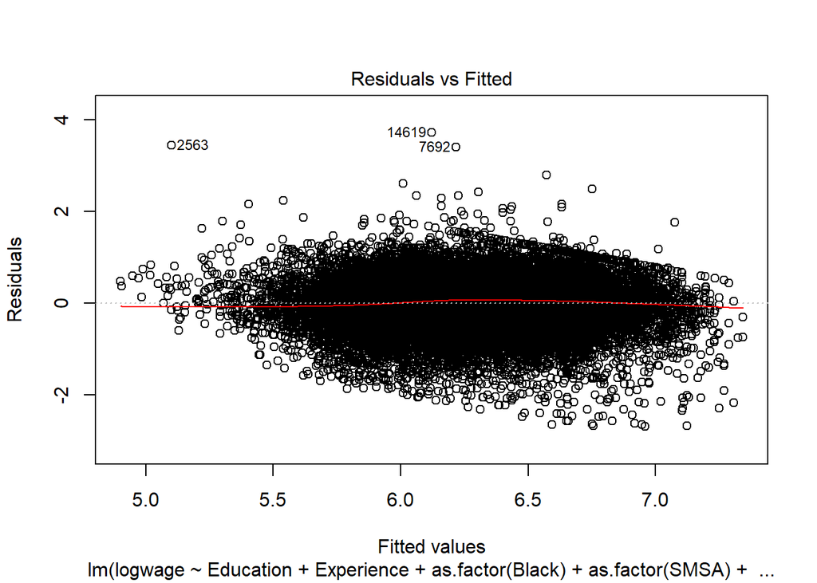

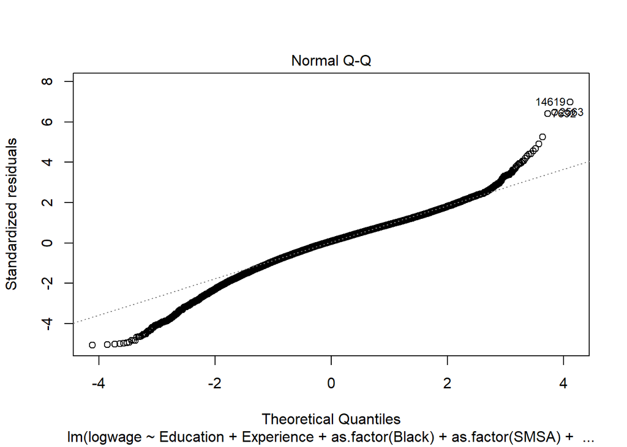

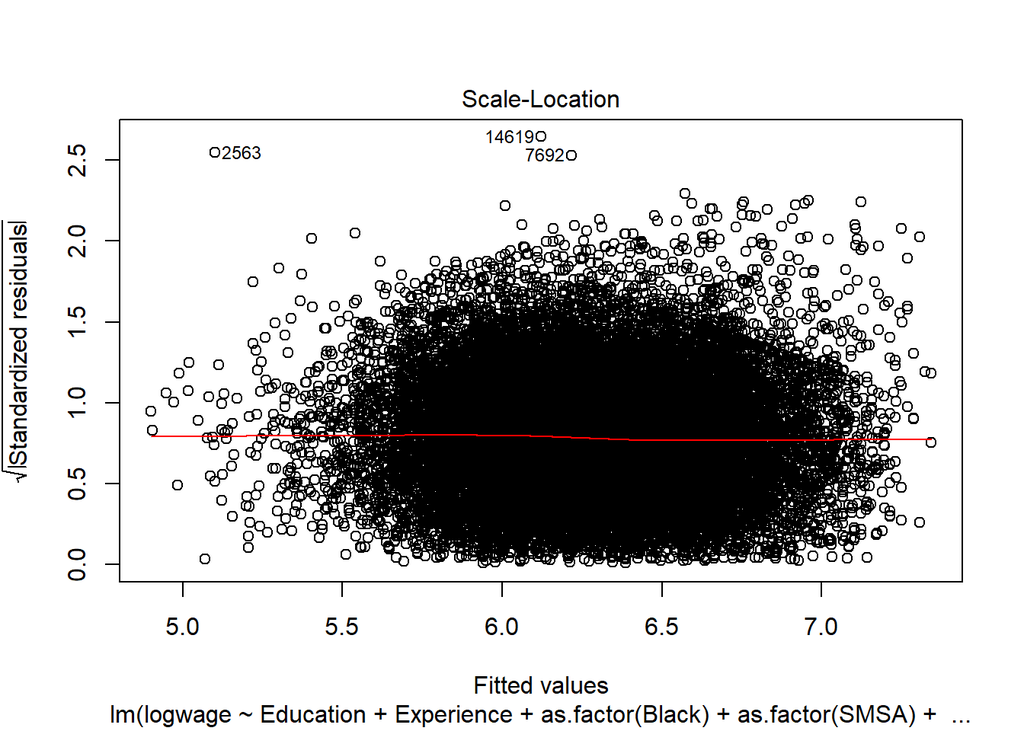

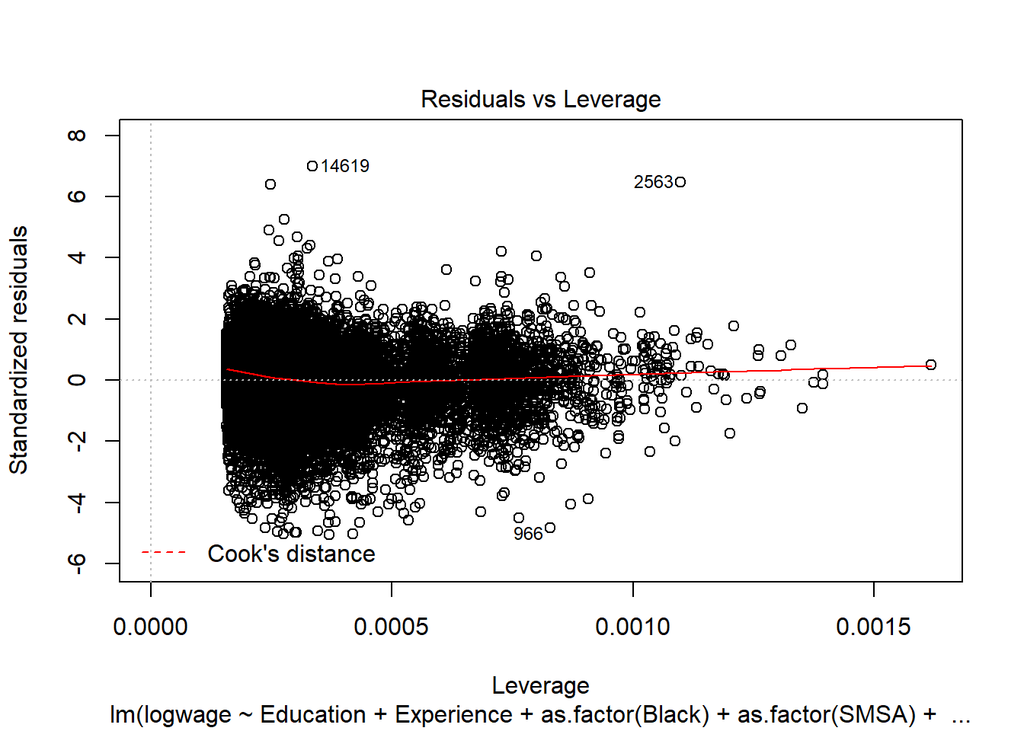

```r
plot(regwage)
```

We can see from the qq plot that line bends at the begining and also at the end and hence the residual does not perfectly exhibit a normal distribution.

```r
regwage_interaction = lm(logwage ~ Education + Experience + as.factor(Black) + as.factor(SMSA) + as.factor(Region) + as.factor(Region)*as.factor(Black), data= wages_df)

summary(regwage_interaction )
```

```
##
## Call:
## lm(formula = logwage ~ Education + Experience + as.factor(Black) +
##     as.factor(SMSA) + as.factor(Region) + as.factor(Region) *
##     as.factor(Black), data = wages_df)
##
## Residuals:
##     Min      1Q  Median      3Q     Max
## -2.6943 -0.3019  0.0443  0.3454  3.7167
##
## Coefficients:
##                                           Estimate Std. Error t value
## (Intercept)                              4.5774253  0.0197466 231.808
## Education                                0.0969922  0.0012015  80.723
## Experience                               0.0183495  0.0002789  65.791
## as.factor(Black)Yes                     -0.2406660  0.0305139  -7.887
## as.factor(SMSA)Yes                       0.1575999  0.0077298  20.389
## as.factor(Region)NE                      0.0347743  0.0099861   3.482
## as.factor(Region)S                      -0.0606862  0.0094570  -6.417
## as.factor(Region)W                      -0.0034929  0.0100704  -0.347
## as.factor(Black)Yes:as.factor(Region)NE  0.0226109  0.0428692   0.527
## as.factor(Black)Yes:as.factor(Region)S   0.0033072  0.0348394   0.095
## as.factor(Black)Yes:as.factor(Region)W   0.0468973  0.0510170   0.919
##                                         Pr(>|t|)
## (Intercept)                              < 2e-16 ***
## Education                                < 2e-16 ***
## Experience                               < 2e-16 ***
## as.factor(Black)Yes                     3.22e-15 ***
## as.factor(SMSA)Yes                       < 2e-16 ***
## as.factor(Region)NE                     0.000498 ***
## as.factor(Region)S                      1.41e-10 ***
## as.factor(Region)W                      0.728705
## as.factor(Black)Yes:as.factor(Region)NE 0.597893
## as.factor(Black)Yes:as.factor(Region)S  0.924374
## as.factor(Black)Yes:as.factor(Region)W  0.357975
## ---
## Signif. codes:  0 '***' 0.001 '**' 0.01 '*' 0.05 '.' 0.1 ' ' 1
##
## Residual standard error: 0.5314 on 25620 degrees of freedom
## Multiple R-squared:  0.2828, Adjusted R-squared:  0.2825
## F-statistic:  1010 on 10 and 25620 DF,  p-value: < 2.2e-16
```

```r
confint(regwage_interaction )
```

```
##                                               2.5 %      97.5 %
## (Intercept)                              4.53872079  4.61612978
## Education                                0.09463713  0.09934731
## Experience                               0.01780280  0.01889614
## as.factor(Black)Yes                     -0.30047505 -0.18085694
## as.factor(SMSA)Yes                       0.14244906  0.17275072
## as.factor(Region)NE                      0.01520101  0.05434753
## as.factor(Region)S                      -0.07922237 -0.04215000
## as.factor(Region)W                      -0.02323149  0.01624561
## as.factor(Black)Yes:as.factor(Region)NE -0.06141522  0.10663709
## as.factor(Black)Yes:as.factor(Region)S  -0.06498005  0.07159441
## as.factor(Black)Yes:as.factor(Region)W  -0.05309896  0.14689354
```

We can see that the r_squared is 0.2828 and SE is 0.5314.

Lets perform the nested F test:

```r
anova(regwage_interaction,regwage )
```

```
## Analysis of Variance Table
##
## Model 1: logwage ~ Education + Experience + as.factor(Black) + as.factor(SMSA) +
##     as.factor(Region) + as.factor(Region) * as.factor(Black)
## Model 2: logwage ~ Education + Experience + as.factor(Black) + as.factor(SMSA) +
##     as.factor(Region)
##   Res.Df    RSS Df Sum of Sq     F Pr(>F)
## 1  25620 7234.7
## 2  25623 7235.1 -3  -0.35328 0.417 0.7408
```

We can see that the F statiscs is 0.417 and p value is 0.7408. The p value suggest that the interactions are not statsically significant and des not add value to this model.

```r
Experience_square = wages_df$Experience^2

regwage_final = lm(logwage ~ Education + Experience + Experience_square + as.factor(Black) + as.factor(SMSA) + as.factor(Region), data= wages_df)


summary(regwage_final)
```

```
##
## Call:
## lm(formula = logwage ~ Education + Experience + Experience_square +
##     as.factor(Black) + as.factor(SMSA) + as.factor(Region), data = wages_df)
##
## Residuals:
##     Min      1Q  Median      3Q     Max
## -2.7119 -0.2858  0.0348  0.3259  3.9170
##
## Coefficients:
##                       Estimate Std. Error t value Pr(>|t|)
## (Intercept)          4.412e+00  1.933e-02 228.235  < 2e-16 ***
## Education            8.833e-02  1.173e-03  75.306  < 2e-16 ***
## Experience           5.626e-02  8.886e-04  63.311  < 2e-16 ***
## Experience_square   -8.600e-04  1.922e-05 -44.751  < 2e-16 ***
## as.factor(Black)Yes -2.334e-01  1.219e-02 -19.145  < 2e-16 ***
## as.factor(SMSA)Yes   1.641e-01  7.427e-03  22.091  < 2e-16 ***
## as.factor(Region)NE  4.359e-02  9.354e-03   4.660 3.18e-06 ***
## as.factor(Region)S  -6.251e-02  8.735e-03  -7.156 8.55e-13 ***
## as.factor(Region)W  -1.119e-02  9.500e-03  -1.178    0.239
## ---
## Signif. codes:  0 '***' 0.001 '**' 0.01 '*' 0.05 '.' 0.1 ' ' 1
##
## Residual standard error: 0.5118 on 25622 degrees of freedom
## Multiple R-squared:  0.3347, Adjusted R-squared:  0.3345
## F-statistic:  1611 on 8 and 25622 DF,  p-value: < 2.2e-16
```

We can see that R-squared is 0.3347 and the Standard Error is 0.5118.

The confidence interval of the variables are:

```r
exp(confint(regwage_final))
```

```
##                          2.5 %    97.5 %
## (Intercept)         79.3354934 85.580526
## Education            1.0898389  1.094862
## Experience           1.0560268  1.059712
## Experience_square    0.9991027  0.999178
## as.factor(Black)Yes  0.7731625  0.811006
## as.factor(SMSA)Yes   1.1612718  1.195580
## as.factor(Region)NE  1.0255781  1.063884
## as.factor(Region)S   0.9234603  0.955630
## as.factor(Region)W   0.9706303  1.007459
```

This means that 95% times the model captures the true value of the variable.

Interpretation:

Black: Keeping other values constant, if the person is black then the mutliplicative factor associated with the median of wages changes by 0.7918368. CI is between 0.7731625 and 0.811006

Education: Keep the other value constant, if the Education changes by 1 unit then the multiplicative factor accociated with median of wages changes by 1.092349. CI is between 1.0898389 and 1.094862

SMSA: Keeping the other values constant, if the its a metro then the multiplicative factor associated with the median of the wage changes by 1.178332. CI is between 1.1612718 and 1.195580

Region: Keeping the other values constant, if the Region is NE then the multiplicative factor associated with the median of the wage chnages by 1.044554. CI is between 1.0255781 and 1.063884

Keeping the other values constant, if the Region is S then the multiplicative factor associated with the median of the wage chnages by 0.9394037. CI is between 0.9234603 and 0.955630.

Keeping the other values constant, if the Region is W then the multiplicative factor associated with the median of the wage chnages by 0.9888724. CI is between 0.9706303 and 1.007459.

Experience: We can understand the effect of experience on speed by plotting a graph:

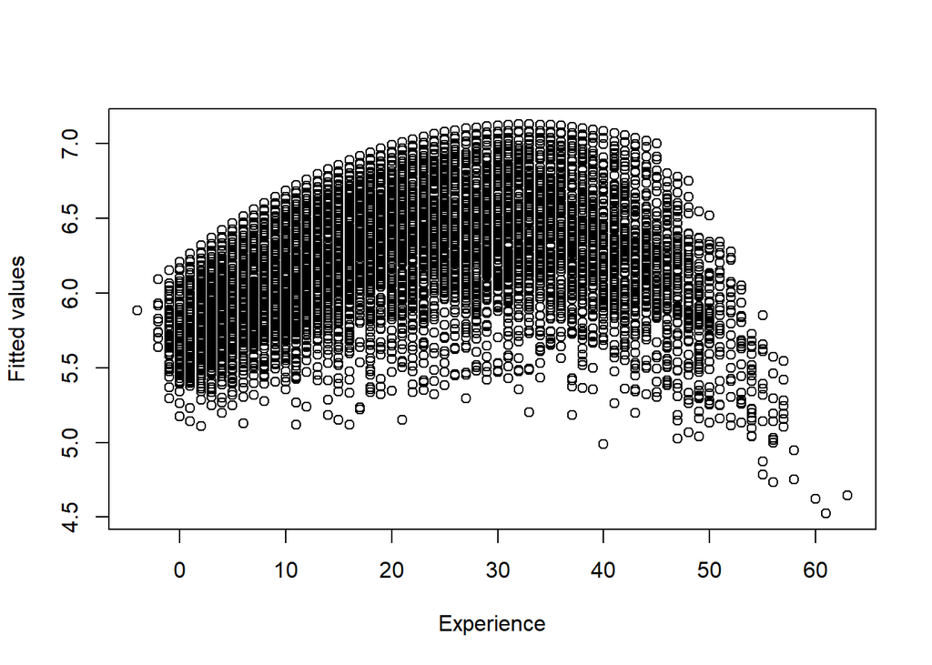

```r
plot(y = regwage_final$fitted.values, x = wages_df$Experience, xlab ="Experience", ylab = "Fitted values")
```

Plot the residuals against all the independnt variables and fitted values.

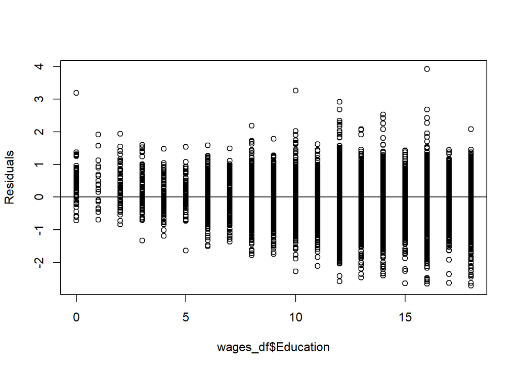

```r
plot(regwage_final$residuals, x= wages_df$Education, ylab = "Residuals")
abline(0,0)
```

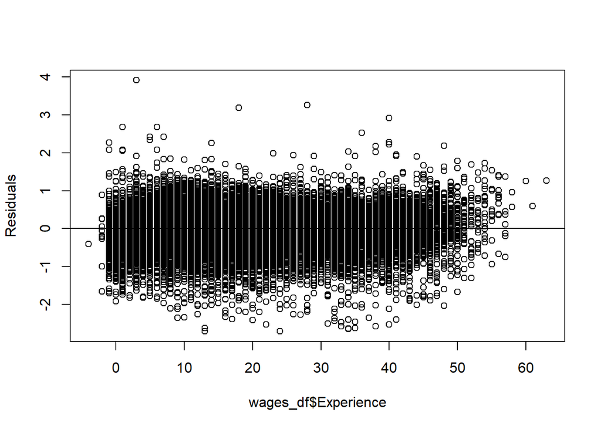

```r
plot(regwage_final$residuals, x= wages_df$Experience, ylab = "Residuals")
abline(0,0)
```

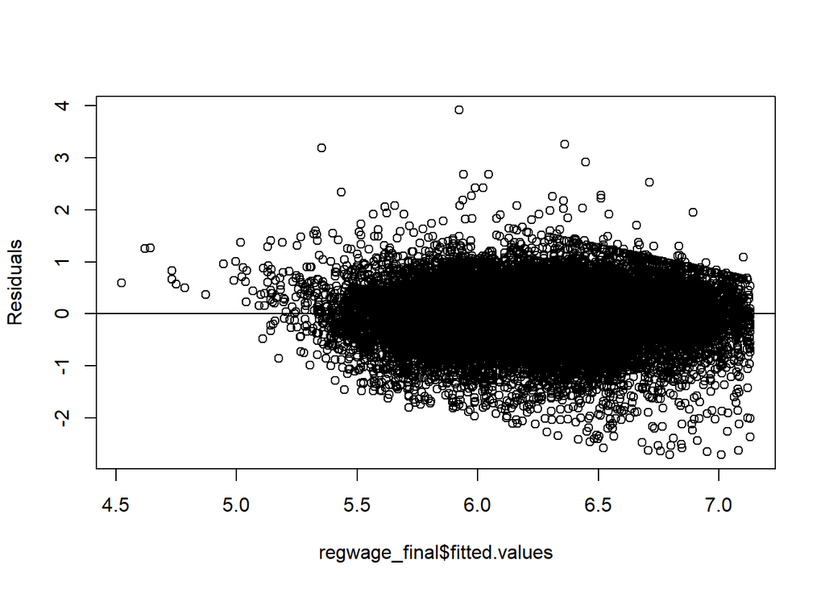

```r
plot(regwage_final$residuals, x= regwage_final$fitted.values, ylab = "Residuals")
abline(0,0)
```

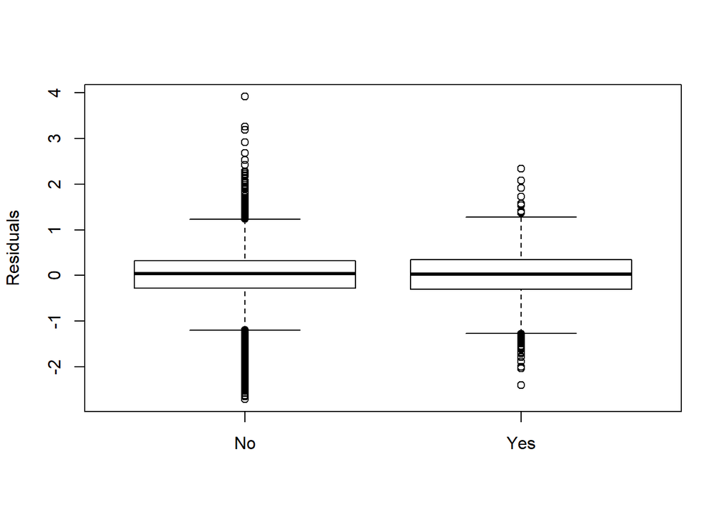

```r
boxplot(regwage_final$residuals~wages_df$Black, ylab = "Residuals")
```

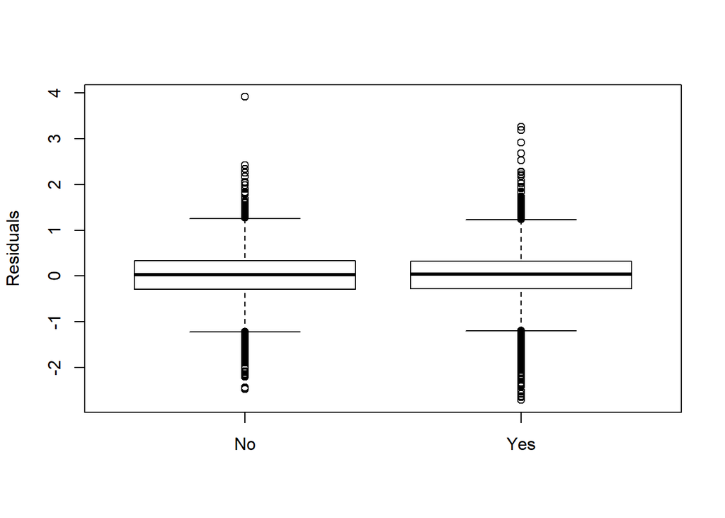

```r
boxplot(regwage_final$residuals~wages_df$SMSA, ylab = "Residuals")
```

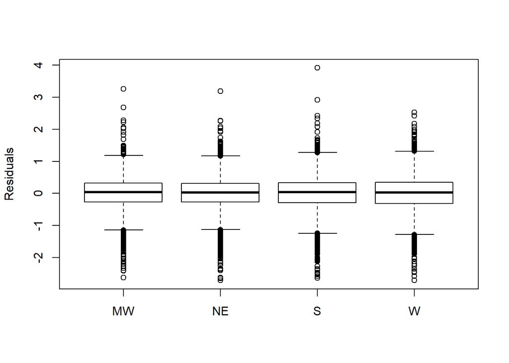

```r
boxplot(regwage_final$residuals~wages_df$Region, ylab = "Residuals")
```

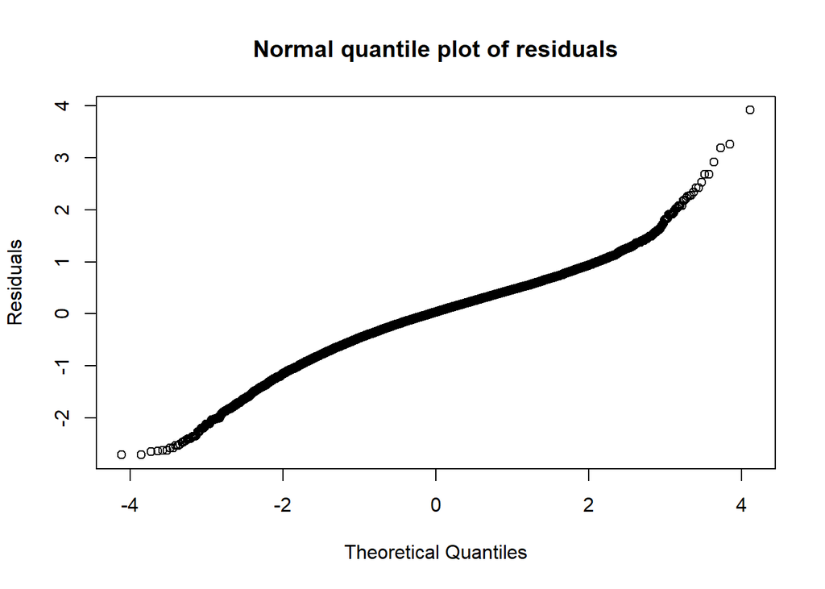

```r
qqnorm(regwage_final$residuals, ylab = "Residuals", main = "Normal quantile plot of residuals")
```

Based on the residual plots and box plot we can see that residual does not exhibit constant variance.

The qq plot shows that some points are not on the line and hence does not completely statisfy normal distribution.

Limitation: The r_sqaured value is really low for the model. It is somewhat difficult to explain the model as we are using experience square (quadratic function) The residual does not show constant variance. The rediusal does not follow a perfect normal distribution.